# Unit 4 - “Judge, Jury, and Classifier” Lecture

#### Read in the data

```r
stevens = read.csv("stevens.csv")
str(stevens)
```

```
## 'data.frame':    566 obs. of  9 variables:
##  $ Docket    : Factor w/ 566 levels "00-1011","00-1045",..: 63 69 70 145 97 181 242 289 334 436 ...
##  $ Term      : int  1994 1994 1994 1994 1995 1995 1996 1997 1997 1999 ...
##  $ Circuit   : Factor w/ 13 levels "10th","11th",..: 4 11 7 3 9 11 13 11 12 2 ...
##  $ Issue     : Factor w/ 11 levels "Attorneys","CivilRights",..: 5 5 5 5 9 5 5 5 5 3 ...
##  $ Petitioner: Factor w/ 12 levels "AMERICAN.INDIAN",..: 2 2 2 2 2 2 2 2 2 2 ...
##  $ Respondent: Factor w/ 12 levels "AMERICAN.INDIAN",..: 2 2 2 2 2 2 2 2 2 2 ...
##  $ LowerCourt: Factor w/ 2 levels "conser","liberal": 2 2 2 1 1 1 1 1 1 1 ...
##  $ Unconst   : int  0 0 0 0 0 1 0 1 0 0 ...
##  $ Reverse   : int  1 1 1 1 1 0 1 1 1 1 ...
```

- $Docket : a unique identifier for each case
- $Term : year

Independent variables

- $Circuit : circuit court of origin
- $Issue : the issue area of the case
- $Petitioner : the type of the petitioner
- $Respondent : the type of the respondent
- $LowerCourt : the lower court direction
- $Unconst : whether or not the petitioner argued that a low or practice was unconstitutional

Dependent variable

- $Reverse : whether or not Justice Stevens voted to reverse the case

#### Split the data

```r
library(caTools)
set.seed(200)
spl = sample.split(stevens$Reverse, SplitRatio = 0.7)
Train = subset(stevens, spl==TRUE)
Test = subset(stevens, spl==FALSE)
```

#### Install rpart library

```r
#install.packages("rpart")
library(rpart)
```

```r
#install.packages("rpart.plot")
library(rpart.plot)
```

### CART model

```r
StevensTree = rpart(Reverse ~ Circuit + Issue + Petitioner + Respondent + LowerCourt + Unconst, data = Train, method="class", minbucket=25)
```

- `method="class"` : This tells `rpart` to build a classification tree, instead of a regression tree
- `minbucket=25` : This limits the tree, so that it doesn’t overfit to our training set. If minbucket=5, we have 16 splits and if minbucket=100, we only have 1 split.

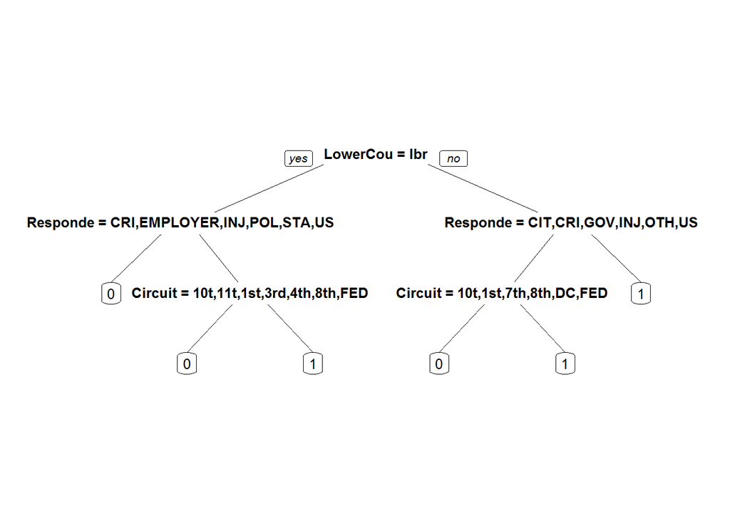

```r
prp(StevensTree)
```

- The first split of our tree is whether or not the lower court decision is liberal
- If the respondent is a criminal dependent, injured person, politician, state, or the United States, it well be an **affirm (0)**
- Comparing CART to a logistic regression model, we can see that it’s very **interpretable**.
- A CART model is **a series of decision rules** which can easily be explained.

#### Make predictions

```r
PredictCART = predict(StevensTree, newdata = Test, type = "class")
```

- `type="class"` : we need to give this argument when making predictions for our CART model if we want the majority class predictions. That is, this is like using a treshold of 0.5

```r
table(Test$Reverse, PredictCART)
```

```
##    PredictCART
##      0  1
##   0 35 42
##   1 26 67
```

```r
(35+67)/(35+67+42+26)
```

```
## [1] 0.6
```

#### ROC curve

```r
library(ROCR)
PredictROC = predict(StevensTree, newdata = Test)
PredictROC
```

```
##             0         1
## 4   0.1444444 0.8555556
## 5   0.1444444 0.8555556
## 6   0.1444444 0.8555556
## 7   0.1444444 0.8555556
## 8   0.1444444 0.8555556
## 14  0.3888889 0.6111111
## 21  0.3888889 0.6111111
## 28  0.3888889 0.6111111
## 34  0.1444444 0.8555556
## 35  0.1444444 0.8555556
## 36  0.6603774 0.3396226
## 42  0.3888889 0.6111111
## 44  0.1444444 0.8555556
## 55  0.3888889 0.6111111
```

[output cut: 156 more lines]

More concretely, each test set observation is classified into a subset.

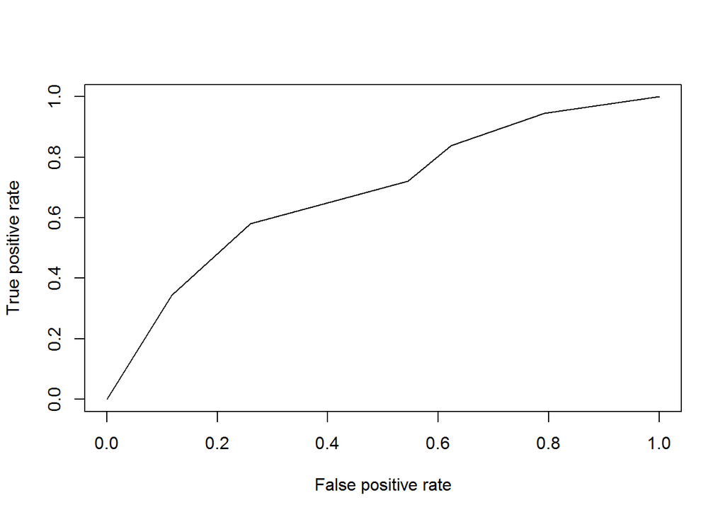

```r
pred = prediction(PredictROC[,2], Test$Reverse) # we'll use the second column as our probabilities to generate an ROC Curve
perf = performance(pred, "tpr", "fpr")
plot(perf)
```

```r
as.numeric(performance(pred, "auc")@y.values)
```

```
## [1] 0.6856584
```

### Random Forests

#### Install randomForest package

```r
#install.packages("randomForest")
library(randomForest)
```

#### Build random forest model

```r
StevensForest = randomForest(Reverse ~ Circuit + Issue + Petitioner + Respondent + LowerCourt + Unconst, data = Train, ntree=200, nodesize=25 )
```

#### Convert outcome to factor

```r
Train$Reverse = as.factor(Train$Reverse)
Test$Reverse = as.factor(Test$Reverse)
```

In CART, we added the argument `method="class"`, so that it was clear that we’re doing a classification problem. (Trees can also be used for regression problems.) On the other hand, the Random Forest function does not have a method argument. so, when we want to do a classification problem, we need to make sure outcome is a **factor**.

#### Try again

```r
StevensForest = randomForest(Reverse ~ Circuit + Issue + Petitioner + Respondent + LowerCourt + Unconst, data = Train, ntree=200, nodesize=25 )
```

#### Make predictions

```r
PredictForest = predict(StevensForest, newdata = Test)
table(Test$Reverse, PredictForest)
```

```
##    PredictForest
##      0  1
##   0 43 34
##   1 20 73
```

```r
(43+73)/(43+73+34+20)
```

```
## [1] 0.6823529
```

In general, in terms of accuracy, Logistic regression < CART(0.6) < Random Forest(0.6823529). As we see here, the random component of the random forest method can change the accuracy. The accuracy for a more stable dataset will not change very much, but a **noisy dataset** can be significantly affected by the random samples.

### Cross-Validation

#### Install cross-validation packages

```r
#install.packages("caret")
library(caret)
#install.packages("e1071")
library(e1071)
```

#### Define cross-validation experiment

```r
numFolds = trainControl( method = "cv", number = 10 ) # Cross-Validation, k=10
cpGrid = expand.grid( .cp = seq(0.01,0.5,0.01))
```

We need to pick the possible values for cp parameters, using the `expand.grid` function

#### Perform the cross validation

```r
train(Reverse ~ Circuit + Issue + Petitioner + Respondent + LowerCourt + Unconst, data = Train, method = "rpart", trControl = numFolds, tuneGrid = cpGrid ) # "rpart" : CART model
```

```
## CART
##
## 396 samples
##   8 predictor
##   2 classes: '0', '1'
##
## No pre-processing
## Resampling: Cross-Validated (10 fold)
## Summary of sample sizes: 356, 357, 357, 356, 356, 357, ...
## Resampling results across tuning parameters:
##
##   cp    Accuracy   Kappa       Accuracy SD  Kappa SD
##   0.01  0.6538462  0.29054260  0.062801614  0.12950848
##   0.02  0.6436538  0.27521047  0.055747081  0.11699416
##   0.03  0.6461538  0.28489865  0.048407694  0.10441368
##   0.04  0.6537179  0.30447768  0.043908879  0.09374528
##   0.05  0.6614103  0.32119925  0.047986905  0.10186976
##   0.06  0.6614103  0.32119925  0.047986905  0.10186976
##   0.07  0.6614103  0.32119925  0.047986905  0.10186976
##   0.08  0.6614103  0.32119925  0.047986905  0.10186976
##   0.09  0.6614103  0.32119925  0.047986905  0.10186976
##   0.10  0.6614103  0.32119925  0.047986905  0.10186976
##   0.11  0.6614103  0.32119925  0.047986905  0.10186976
##   0.12  0.6614103  0.32119925  0.047986905  0.10186976
##   0.13  0.6614103  0.32119925  0.047986905  0.10186976
##   0.14  0.6614103  0.32119925  0.047986905  0.10186976
##   0.15  0.6614103  0.32119925  0.047986905  0.10186976
##   0.16  0.6614103  0.32119925  0.047986905  0.10186976
##   0.17  0.6614103  0.32119925  0.047986905  0.10186976
##   0.18  0.6614103  0.32119925  0.047986905  0.10186976
##   0.19  0.6614103  0.32119925  0.047986905  0.10186976
##   0.20  0.6614103  0.32119925  0.047986905  0.10186976
##   0.21  0.6614103  0.32119925  0.047986905  0.10186976
##   0.22  0.6614103  0.32119925  0.047986905  0.10186976
##   0.23  0.6614103  0.32119925  0.047986905  0.10186976
##   0.24  0.6614103  0.32119925  0.047986905  0.10186976
##   0.25  0.6084615  0.18673042  0.048700889  0.13886578
##   0.26  0.5657051  0.06434802  0.032109989  0.10541042
##   0.27  0.5505128  0.01680000  0.014818650  0.05312626
##   0.28  0.5453846  0.00000000  0.005958436  0.00000000
```

[output cut: 10 more lines]

```
##   0.39  0.5453846  0.00000000  0.005958436  0.00000000
##   0.40  0.5453846  0.00000000  0.005958436  0.00000000
##   0.41  0.5453846  0.00000000  0.005958436  0.00000000
##   0.42  0.5453846  0.00000000  0.005958436  0.00000000
##   0.43  0.5453846  0.00000000  0.005958436  0.00000000
##   0.44  0.5453846  0.00000000  0.005958436  0.00000000
##   0.45  0.5453846  0.00000000  0.005958436  0.00000000
##   0.46  0.5453846  0.00000000  0.005958436  0.00000000
##   0.47  0.5453846  0.00000000  0.005958436  0.00000000
##   0.48  0.5453846  0.00000000  0.005958436  0.00000000
##   0.49  0.5453846  0.00000000  0.005958436  0.00000000
##   0.50  0.5453846  0.00000000  0.005958436  0.00000000
##
## Accuracy was used to select the optimal model using  the largest value.
## The final value used for the model was cp = 0.24.
```

#### Create a new CART model

```r
StevensTreeCV = rpart(Reverse ~ Circuit + Issue + Petitioner + Respondent + LowerCourt + Unconst, data = Train, method="class", cp = 0.24)
```

#### Make predictions

```r
PredictCV = predict(StevensTreeCV, newdata = Test, type = "class")
table(Test$Reverse, PredictCV)
```

```
##    PredictCV
##      0  1
##   0 51 26
##   1 28 65
```

```r
(51+65)/(51+65+26+28)
```

```
## [1] 0.6823529
```

- previous CART: (0.6) < new CART with CV (0.682359)
- Cross validation helps us make sure that we’re selecting a good parameter value and often this will significantly increase the accuracy.
- You might be wondering why we used cross-validation on our CART model, but not on our random forest model. According to the creaters for the random forest algorithm, the model is not very sensitive to the prameters and therefore does not easily overfit to the training set.